# Getting Started with mgcvUI for Real Estate Appraisers

## What is mgcvUI?

mgcvUI is an interactive tool for building **Generalized Additive Models (GAMs)** – flexible regression models that can capture nonlinear relationships in your data without requiring you to specify the exact shape of each curve.

If you are a real estate appraiser, you already know that the relationship between sale price and living area is not a straight line: the per-square-foot value often changes as homes get larger. A GAM can learn these curves directly from your data, producing a transparent, defensible model.

## Quick Start

### 1. Launch the app

```r
library(mgcvUI)
mgcvUI()
```

This opens mgcvUI in your web browser.

### 2. Import your data

Click **Browse** to select a CSV or Excel file containing your comparable sales. Files are read directly from disk (no upload size limits). mgcvUI remembers the last-used file and auto-loads it on next launch.

### 3. Choose your variables

In the **Predictor Settings** table:

- **Response** – select your sale price column.
- **Inc** – check the predictors you want in the model.
- **Factor** – check categorical variables (e.g., neighborhood, condition).
- **Linear** – check variables that should enter linearly (no smooth curve).
- **Special** – assign column roles like `living_area`, `lot_size`, `area`, `weights`, `latitude`, `longitude`, etc.

mgcvUI automatically configures a smooth curve for each included numeric predictor. Categorical variables enter the model as linear terms.

### 4. Choose your parameter preset

The **Parameter Preset** selector at the top of Mgcv Call Parameters offers two options:

- **Standalone (discovery)** – for GAMs without earth input. Uses `tp` basis, k=auto(10), gamma=1.2. mgcv discovers the nonlinearities.
- **Earth Pipeline (refinement)** – auto-selected when an earthUI result is imported. Uses `cr` basis, k=5, gamma=1.4. mgcv refines earth’s breakpoints.

See the mgcvUI User Guide for full parameter details.

### 5. Fit the model

Click **Fit Model**. mgcvUI fits a GAM using `mgcv::gam()` with your chosen parameters and shows a notification with the fitting time.

### 6. Review the results

The results panel has tabs for:

- **Summary** – R-squared, CV R-squared, AIC, and significance of each term.
- **Contribution** – interactive smooth plots for each predictor, with confidence bands showing statistical uncertainty.
- **Concurvity** – checks for near-concurvity (smooth multicollinearity). Values above 0.8 warrant investigation.
- **Diagnostics** – residual plots and Q-Q plots to check model assumptions.
- **Basis Check** – verifies that the model has enough flexibility.

### 7. Generate a report

Use the download buttons to export estimated sale prices, residuals, and formatted reports (HTML, Word, or PDF) for your appraisal workfile.

## Understanding the Smooth Plots

A flat curve means the predictor has little effect. A steep curve means the predictor is influential.

## Understanding Concurvity

Concurvity is the smooth analog of multicollinearity. If two predictors are highly correlated (e.g., living area and number of rooms), their smooth terms can become nearly interchangeable, making individual effects unreliable.

The **Concurvity** tab shows overall and pairwise concurvity values. Cells are color-coded: white (< 0.5, OK), yellow (0.5–0.8, moderate), red (> 0.8, high). High values mean you should consider dropping or combining correlated terms.

## Adjusting Mgcv Call Parameters

Most users can use the preset defaults. Power users may want to adjust:

- **Basis type** – `tp` (thin plate, the default for standalone) is an excellent all-rounder. `cr` (cubic regression spline) is faster and works well when you have earth knot positions.
- **k** – the basis dimension controls maximum wiggliness. Higher values allow more complex curves. Too high risks overfitting on small comp sets.
- **Gamma** – values greater than 1 produce smoother curves. 1.4 is the Wood & Fasiolo recommendation for parsimony.
- **Select** – when enabled (recommended), terms that contribute little are shrunk toward zero. This is the `select` argument to `mgcv::gam()`.
- **Method** – REML is strongly preferred over GCV.Cp for correlated predictors and modest sample sizes.

## Interactions

### Tensor Interactions (continuous x continuous)

Under “Allowed Interactions”, the matrix shows pairs of smooth predictors. Check a cell to add a `ti()` tensor interaction.

### Factor-by-Smooth Interactions

The “Factor-by-Smooth” grid lets you fit separate smooth curves per factor level. For example, checking `lot_size` x `area_id` generates `s(lot_size, by=area_id)` – a different lot size curve for each neighborhood.

## Programmatic Use

You do not need the Shiny app. The core functions work in plain R:

```r
library(mgcvUI)

specs <- list(
  list(vars = "wt", type = "s", bs = "tp", k = NULL),
  list(vars = "hp", type = "s", bs = "tp", k = NULL)
)

result <- fit_gam(mtcars, "mpg", specs)
```

[output not shown]

```r
format_gam_summary(result)
```

```
#> $r_squared
#> [1] 0.8750128
#>
#> $cv_rsq
#> [1] 0.8034919
#>
#> $dev_explained
#> [1] 0.8917915
#>
#> $aic
#> [1] 148.0093
#>
#> $bic
#> [1] 158.5714
#>
#> $n_obs
#> [1] 32
#>
#> $n_smooths
#> [1] 2
#>
#> $method
#> [1] "REML"
#>
#> $family
#> [1] "gaussian"
#>
#> $smooth_table
#>    Term      EDF Ref.df        F      p_value
#> 1 s(wt) 2.168807      9 4.702704 1.643527e-06
#> 2 s(hp) 1.992731      9 1.949829 4.555070e-04
#>
#> $parametric_table
#>          Term Estimate Std_Error  t_value      p_value
#> 1 (Intercept) 20.09063 0.3766649 53.33819 8.963355e-29
```

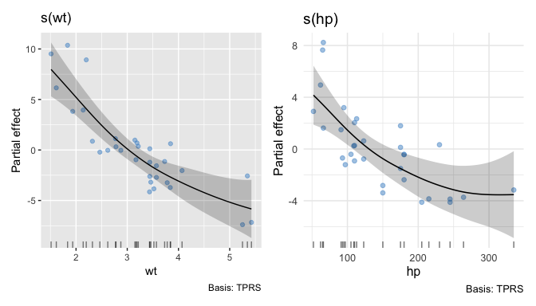

```r
plot_smooths(result)
```

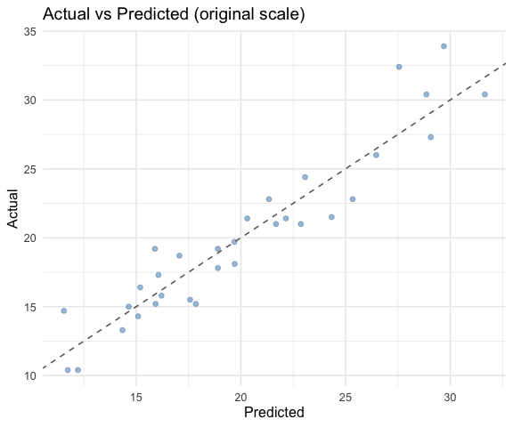

```r
plot_actual_vs_predicted(result)
```